# 00_dde

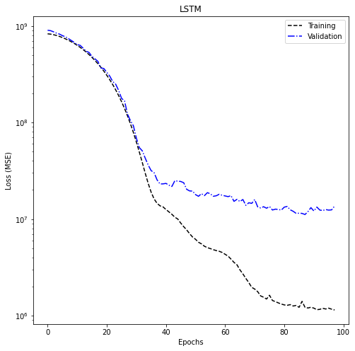

```python
%%skip $SKIP_RETRAIN_LSTM

fig = plot_learning_curves(histMSLSTM,model_type,f'./{model_type}/learningcurve_{namespace}.png')
```

Load best model

```python
model_best_MS_LSTM = keras.models.load_model(f"./{model_type}/my_best_model_{namespace}.h5")
model_best_MS_LSTM.summary()
```

```
Model: "sequential"
_________________________________________________________________
Layer (type)                 Output Shape              Param #
=================================================================
lstm (LSTM)                  (None, None, 64)          23296
_________________________________________________________________
batch_normalization (BatchNo (None, None, 64)          256
_________________________________________________________________
dropout (Dropout)            (None, None, 64)          0
_________________________________________________________________
lstm_1 (LSTM)                (None, None, 64)          33024
_________________________________________________________________
batch_normalization_1 (Batch (None, None, 64)          256
_________________________________________________________________
dropout_1 (Dropout)          (None, None, 64)          0
_________________________________________________________________
lstm_2 (LSTM)                (None, None, 64)          33024
_________________________________________________________________
batch_normalization_2 (Batch (None, None, 64)          256
_________________________________________________________________
dropout_2 (Dropout)          (None, None, 64)          0
_________________________________________________________________
lstm_3 (LSTM)                (None, None, 64)          33024
_________________________________________________________________
batch_normalization_3 (Batch (None, None, 64)          256
_________________________________________________________________
dropout_3 (Dropout)          (None, None, 64)          0
_________________________________________________________________
lstm_4 (LSTM)                (None, None, 64)          33024
_________________________________________________________________
batch_normalization_4 (Batch (None, None, 64)          256
_________________________________________________________________
dropout_4 (Dropout)          (None, None, 64)          0
_________________________________________________________________
lstm_5 (LSTM)                (None, 64)                33024
_________________________________________________________________
dense (Dense)                (None, 64)                4160
_________________________________________________________________
leaky_re_lu (LeakyReLU)      (None, 64)                0
_________________________________________________________________
batch_normalization_5 (Batch (None, 64)                256
_________________________________________________________________
dense_1 (Dense)              (None, 24)                1560
=================================================================
Total params: 195,672
Trainable params: 194,904
Non-trainable params: 768
_________________________________________________________________
```

```python
i=1
case_test = data_x_test[i].reshape((1,data_x_test[0].shape[0], data_x_test[0].shape[1]))

Y_test_predictions = pd.Series(model_best_MS_LSTM.predict(case_test).flatten(),index=pd.date_range(start=idx_test[i],freq='h',periods=24))
y_test_filtered = data_y_test0.loc[Y_test_predictions.index]
```

```python
eval_df = create_eval_df(Y_test_predictions,y_test_filtered)
```

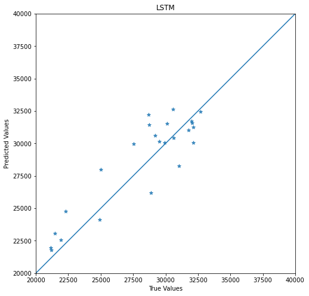

```python
fig = plot_accuracy(eval_df,model_type,f"./{model_type}/accuracy_{namespace}.png")
```

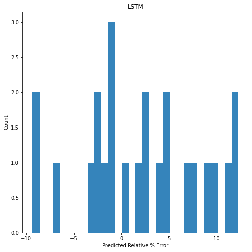

```python
fig = plot_error_variations(eval_df,model_type,f"./{model_type}/error_variations_{namespace}.png")
```

```python
abs_error_MSLSTM = abs(Y_test_predictions - y_test_filtered)/y_test_filtered*100
np.average(abs_error_MSLSTM)
```

```
nan
```

```python
r2_test = r2_score(y_test_filtered, Y_test_predictions)
print('R^2 score is  %3.2f' %r2_test)
```

```
R^2 score is  0.79
```

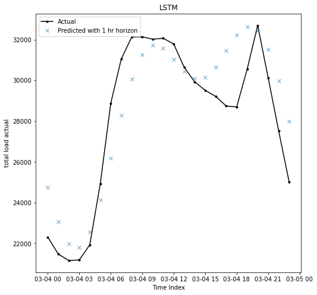

```python
fig = plot_predictions(eval_df,1,model_type,feature,f"./{model_type}/predictions_{namespace}")
```

```python
idx_prediction = pd.date_range(start=idx_test[0],freq='h',periods=len(idx_test)+24)
y_test_filtered2 = data_y_test0.loc[idx_prediction]
```

```python
fig = go.Figure()
df_pred =pd.DataFrame(index=y_test_filtered2.index)
fig.add_trace(go.Scatter(x = y_test_filtered2.index,y=y_test_filtered2[feature]))
for i in range(len(data_x_test)):
    case_test = data_x_test[i].reshape((1,data_x_test[0].shape[0], data_x_test[0].shape[1]))
    Y_test_predictions = pd.Series(model_best_MS_LSTM.predict(case_test).flatten(),index=pd.date_range(start=idx_test[i],freq='h',periods=24))
    df_pred[f'pred_{i}'] = Y_test_predictions
    fig.add_trace(go.Scatter(x = Y_test_predictions.index,y=Y_test_predictions,mode='markers'))

df_pred['mean'] = df_pred.mean(axis=1)
df_pred['median'] = df_pred.median(axis=1)
fig.add_trace(go.Scatter(x = y_test_filtered2.index,y=df_pred['mean']))
fig.add_trace(go.Scatter(x = y_test_filtered2.index,y=df_pred['median']))
fig.show()
eval_df2  =create_eval_df(df_pred['mean'],y_test_filtered2)
```

```python
#Calculating R2 value:
r2_test = r2_score(y_test_filtered2[:-1],df_pred['mean'][:-1])
print('R^2 score is  %3.2f' %r2_test)
```

```
R^2 score is  0.77
```

## Encoder-Decoder + LSTM

Scale the input data

```python
scaled_df = combined_df.copy(deep=True)
featuresToScale = scaled_df.columns
sX = pp.StandardScaler(copy=True)
scaled_df.loc[:,featuresToScale] = sX.fit_transform(scaled_df[featuresToScale])
```

Create Train Validation Test Split

```python
train_start = '2015-01-01'
validation_start = '2017-01-01'
test_start = '2017-03-01'
test_end = '2017-03-14'
feature = 'total load actual'
namespace= 'MS_EDLSTM_LOAD'
modeltype = 'EDLSTM'
feature_df = combined_df[[feature]]
data_x_train0,data_x_val0,data_x_test0,data_y_train0,data_y_val0,data_y_test0 = create_test_train_split(scaled_df,feature_df,train_start,test_start,test_end,validation_start=validation_start)
```

Convert to (sample,timestep,feature) format

```python
data_x_train,data_y_train,idx_train = convert_to_sample_time_feature(data_x_train0,data_y_train0,72,24,32)
data_x_test,data_y_test,idx_test = convert_to_sample_time_feature(data_x_test0,data_y_test0,72,24,32)
data_x_val,data_y_val,idx_val = convert_to_sample_time_feature(data_x_val0,data_y_val0,72,24,32)
```

```python
print(data_x_train.shape,data_y_train.shape)
print(data_x_val.shape,data_y_val.shape)
print(data_x_test.shape,data_y_test.shape)
```

```
(17416, 72, 26) (17416, 24)
(1288, 72, 26) (1288, 24)
(168, 72, 26) (168, 24)
```

Define ED LSTM Model

```python
def build_model_ED_LSTM(data_x_train,data_y_train):
    n_timesteps, n_features, n_outputs = data_x_train.shape[1], data_x_train.shape[2], data_y_train.shape[1]
    model = models.Sequential([
    layers.LSTM(80, return_sequences=True,input_shape=(None, n_features), stateful=False),
    layers.BatchNormalization(),
    layers.LSTM(64, return_sequences=True, stateful=False),
    layers.BatchNormalization(),
    layers.LSTM(32, return_sequences=False, stateful=False),
    layers.BatchNormalization(),
    layers.RepeatVector(n_outputs),
    # define decoder:
    layers.LSTM(32, return_sequences=True, stateful=False),
    layers.BatchNormalization(),
    layers.LSTM(64, return_sequences=True, stateful=False),
    layers.BatchNormalization(),
    layers.LSTM(80, return_sequences=True, stateful=False),
    layers.BatchNormalization(),
    layers.TimeDistributed(layers.Dense(1))
    ])
    model.compile(optimizer='Adam',loss='mse',metrics='mae')
    return model
```

Definening callback functions

```python
myCheckpointEDLSTM= keras.callbacks.ModelCheckpoint(f"./{modeltype}/my_best_model_{namespace}.h5", save_best_only=True)
myEarly_stoppingEDLSTM = keras.callbacks.EarlyStopping(patience=20,restore_best_weights=True)
```

Hypterparameters

```python
num_epochs = 150
batch_size = 32
```

Training the model

```python
model_ED_LSTM = build_model_ED_LSTM(data_x_train,data_y_train)
model_ED_LSTM.summary()
```

```
Model: "sequential_5"
_________________________________________________________________
Layer (type)                 Output Shape              Param #
=================================================================
lstm_9 (LSTM)                (None, None, 80)          34240
_________________________________________________________________
batch_normalization_16 (Batc (None, None, 80)          320
_________________________________________________________________
lstm_10 (LSTM)               (None, None, 64)          37120
_________________________________________________________________
batch_normalization_17 (Batc (None, None, 64)          256
_________________________________________________________________
lstm_11 (LSTM)               (None, 32)                12416
_________________________________________________________________
batch_normalization_18 (Batc (None, 32)                128
_________________________________________________________________
repeat_vector (RepeatVector) (None, 24, 32)            0
_________________________________________________________________
lstm_12 (LSTM)               (None, 24, 32)            8320
_________________________________________________________________
batch_normalization_19 (Batc (None, 24, 32)            128
_________________________________________________________________
lstm_13 (LSTM)               (None, 24, 64)            24832
_________________________________________________________________
batch_normalization_20 (Batc (None, 24, 64)            256
_________________________________________________________________
lstm_14 (LSTM)               (None, 24, 80)            46400
_________________________________________________________________
batch_normalization_21 (Batc (None, 24, 80)            320
_________________________________________________________________
time_distributed (TimeDistri (None, 24, 1)             81
=================================================================
Total params: 164,817
Trainable params: 164,113
Non-trainable params: 704
_________________________________________________________________
```

```python
%%skip $SKIP_RETRAIN_ED_LSTM

history_ED_LSTM = model_ED_LSTM.fit(data_x_train, data_y_train, epochs=num_epochs, batch_size=batch_size, validation_data=(data_x_val, data_y_val) ,
                                 callbacks=[myCheckpointEDLSTM,myEarly_stoppingEDLSTM])
```

Evaluate the training process

```python
%%skip $SKIP_RETRAIN_ED_LSTM

histEDLSTM = pd.DataFrame(history_ED_LSTM.history)
histEDLSTM['epoch'] = history_ED_LSTM.epoch
```

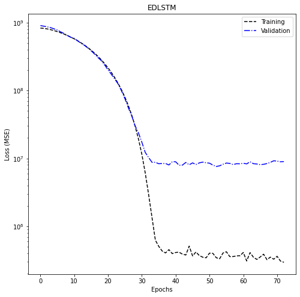

```python
%%skip $SKIP_RETRAIN_ED_LSTM

fig = plot_learning_curves(histEDLSTM,modeltype,f"./{modeltype}/learningcurve_{namespace}.png")
```

Load best model

```python
#Calling back the best model:
model_best_ED_LSTM = keras.models.load_model(f"./{modeltype}/my_best_model_{namespace}.h5")
model_best_ED_LSTM.summary()
```

```
Model: "sequential_5"
_________________________________________________________________
Layer (type)                 Output Shape              Param #
=================================================================
lstm_9 (LSTM)                (None, None, 80)          34240
_________________________________________________________________
batch_normalization_16 (Batc (None, None, 80)          320
_________________________________________________________________
lstm_10 (LSTM)               (None, None, 64)          37120
_________________________________________________________________
batch_normalization_17 (Batc (None, None, 64)          256
_________________________________________________________________
lstm_11 (LSTM)               (None, 32)                12416
_________________________________________________________________
batch_normalization_18 (Batc (None, 32)                128
_________________________________________________________________
repeat_vector (RepeatVector) (None, 24, 32)            0
_________________________________________________________________
lstm_12 (LSTM)               (None, 24, 32)            8320
_________________________________________________________________
batch_normalization_19 (Batc (None, 24, 32)            128
_________________________________________________________________
lstm_13 (LSTM)               (None, 24, 64)            24832
_________________________________________________________________
batch_normalization_20 (Batc (None, 24, 64)            256
_________________________________________________________________
lstm_14 (LSTM)               (None, 24, 80)            46400
_________________________________________________________________
batch_normalization_21 (Batc (None, 24, 80)            320
_________________________________________________________________
time_distributed (TimeDistri (None, 24, 1)             81
=================================================================
Total params: 164,817
Trainable params: 164,113
Non-trainable params: 704
_________________________________________________________________
```

```python
i=1
case_test = data_x_test[i].reshape((1,data_x_test[0].shape[0], data_x_test[0].shape[1]))

Y_test_predictions = pd.Series(model_best_ED_LSTM.predict(case_test).flatten(),index=pd.date_range(start=idx_test[i],freq='h',periods=24))
y_test_filtered = data_y_test0.loc[Y_test_predictions.index]
```

```python
eval_df = create_eval_df(Y_test_predictions,y_test_filtered)
```

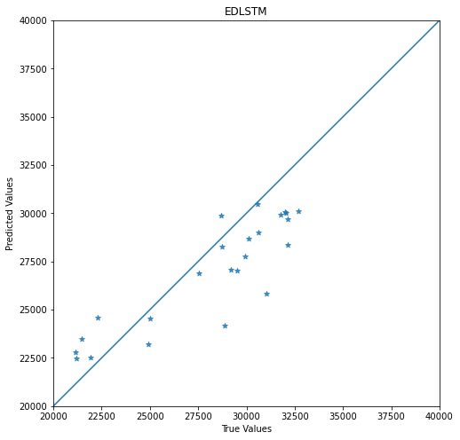

```python
fig = plot_accuracy(eval_df,modeltype,f"./{modeltype}/accuracy_{namespace}.png")
```

```python
abs_error_ED_LSTM = abs(Y_test_predictions - y_test_filtered)/y_test_filtered*100
np.average(abs_error_ED_LSTM)
```

```
nan
```

```python
r2_test = r2_score(y_test_filtered, Y_test_predictions)
print('R^2 score is  %3.2f' %r2_test)
```

```
R^2 score is  0.65
```

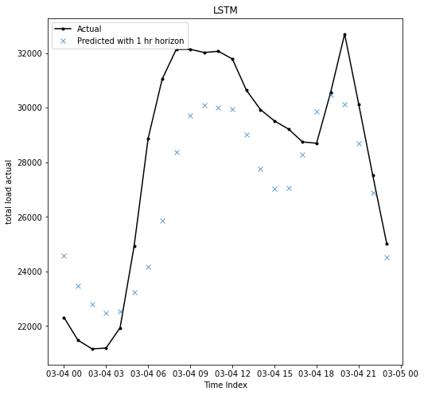

```python
fig=plot_predictions(eval_df,1,model_type,feature,f"./{modeltype}/predictions_{namespace}.png")
```

```python
idx_prediction = pd.date_range(start=idx_test[0],freq='h',periods=len(idx_test)+24)
y_test_filtered2 = data_y_test0.loc[idx_prediction]
```

```python
fig = go.Figure()
df_pred =pd.DataFrame(index=y_test_filtered2.index)
fig.add_trace(go.Scatter(x = y_test_filtered2.index,y=y_test_filtered2[feature]))
for i in range(len(data_x_test)):
    case_test = data_x_test[i].reshape((1,data_x_test[0].shape[0], data_x_test[0].shape[1]))
    Y_test_predictions = pd.Series(model_best_ED_LSTM.predict(case_test).flatten(),index=pd.date_range(start=idx_test[i],freq='h',periods=24))
    df_pred[f'pred_{i}'] = Y_test_predictions
    fig.add_trace(go.Scatter(x = Y_test_predictions.index,y=Y_test_predictions,mode='markers'))

df_pred['mean'] = df_pred.mean(axis=1)
df_pred['median'] = df_pred.median(axis=1)
fig.add_trace(go.Scatter(x = y_test_filtered2.index,y=df_pred['mean']))
fig.add_trace(go.Scatter(x = y_test_filtered2.index,y=df_pred['median']))
fig.show()
eval_df2  =create_eval_df(df_pred['mean'],y_test_filtered2)
```

```python
r2_test = r2_score(y_test_filtered2[:-1],df_pred['mean'][:-1])
print('R^2 score is  %3.2f' %r2_test)
```

```
R^2 score is  0.45
```

# Hyperparameter Tuning

We may investigate the following parameters:

- Number of layers
- Number of nodes
- Activation function
- Optimizer
- Learning rate
- Number of epochs
- Batch size to update the optimization

Other options we can include can be listed as:

- Adding weight regularization
- Adding dropout
- Early stopping / Callback

## LSTM Hyperparameter Tuning

Scale the input data

```python
scaled_df = combined_df.copy(deep=True)
featuresToScale = scaled_df.columns
sX = pp.StandardScaler(copy=True)
scaled_df.loc[:,featuresToScale] = sX.fit_transform(scaled_df[featuresToScale])
```

Create Train Validation Test Split

```python
train_start = '2015-01-01'
validation_start = '2017-01-01'
test_start = '2017-03-01'
test_end = '2017-03-14'
feature = 'total load actual'
modeltype = 'LSTM'
namespace = 'MS_LSTM_LOAD_HPT'
feature_df = combined_df[[feature]]
data_x_train0,data_x_val0,data_x_test0,data_y_train0,data_y_val0,data_y_test0 = create_test_train_split(scaled_df,feature_df,train_start,test_start,test_end,validation_start=validation_start)
```

Convert to (sample,timestep,feature) format

```python
data_x_train,data_y_train,idx_train = convert_to_sample_time_feature(data_x_train0,data_y_train0,72,24,32)
data_x_test,data_y_test,idx_test = convert_to_sample_time_feature(data_x_test0,data_y_test0,72,24,32)
data_x_val,data_y_val,idx_val = convert_to_sample_time_feature(data_x_val0,data_y_val0,72,24,32)
```

```python
print(data_x_train.shape,data_y_train.shape)
print(data_x_val.shape,data_y_val.shape)
print(data_x_test.shape,data_y_test.shape)
```

```
(17416, 72, 26) (17416, 24)
(1288, 72, 26) (1288, 24)
(168, 72, 26) (168, 24)
```

Define LSTM Model for Hyperparamter Tuning

```python
def build_model_LSTM(hp):
    n_timesteps, n_features, n_outputs = data_x_train.shape[1], data_x_train.shape[2], data_y_train.shape[1]
    model = models.Sequential()

    model.add(layers.LSTM(hp.Int('Neurons',min_value=16,max_value=96,step=16), return_sequences=True,input_shape=(None, n_features), stateful=False))
    model.add(layers.BatchNormalization())

    for i in range(hp.Int('n_layers',1,4,1)):
      model.add(layers.LSTM(hp.Int('Neurons',min_value=16,max_value=96,step=16), return_sequences=True, stateful=False))
      model.add(layers.BatchNormalization())

    model.add(layers.LSTM(hp.Int('Neurons',min_value=16,max_value=96,step=16), stateful=False))

    model.add(layers.Dense(hp.Int('Neurons',min_value=16,max_value=96,step=16), kernel_regularizer=regularizers.l2(0.0001), kernel_initializer="he_normal"),)
    model.add(layers.LeakyReLU(alpha=0.1))
    model.add(layers.BatchNormalization())
    model.add(layers.Dense(n_outputs))

    model.compile(optimizer='Adam',loss='mse',metrics='mae')
    return model
```

```python
tuner = kt.RandomSearch(
    build_model_LSTM,
    objective='val_loss',
    max_trials=10,
    executions_per_trial = 1,
    directory = "./hpt_LSTM/",
    project_name="Load")
tuner.search_space_summary()
```

```
INFO:tensorflow:Reloading Oracle from existing project ./hpt_LSTM/Load\oracle.json
INFO:tensorflow:Reloading Tuner from ./hpt_LSTM/Load\tuner0.json
Search space summary
Default search space size: 2
Neurons (Int)
{'default': None, 'conditions': [], 'min_value': 16, 'max_value': 96, 'step': 16, 'sampling': None}
n_layers (Int)
{'default': None, 'conditions': [], 'min_value': 1, 'max_value': 4, 'step': 1, 'sampling': None}
```

```python
myCheckpointLSTM= keras.callbacks.ModelCheckpoint(f"./{modeltype}/my_best_model_{namespace}.h5", save_best_only=True)
myEarly_stoppingLSTM = keras.callbacks.EarlyStopping(patience=10,restore_best_weights=True)
```

```python
num_epochs = 150
batch_size = 32
```

```python
tuner.search(data_x_train,data_y_train,epochs=150,validation_data=(data_x_val,data_y_val),batch_size=batch_size,callbacks=[myCheckpointLSTM,myEarly_stoppingLSTM])
```

```
INFO:tensorflow:Oracle triggered exit
```

```python
tuner.results_summary()
```

```
Results summary
Results in ./hpt_LSTM/Load
Showing 10 best trials
Objective(name='val_loss', direction='min')
Trial summary
Hyperparameters:
Neurons: 80
n_layers: 3
Score: 9466175.0
Trial summary
Hyperparameters:
Neurons: 32
n_layers: 2
Score: 9715865.0
Trial summary
Hyperparameters:
Neurons: 96
n_layers: 1
Score: 10034607.0
Trial summary
Hyperparameters:
Neurons: 48
n_layers: 2
Score: 10114251.0
Trial summary
Hyperparameters:
Neurons: 96
n_layers: 2
Score: 10795117.0
Trial summary
Hyperparameters:
Neurons: 80
n_layers: 4
Score: 11108017.0
Trial summary
Hyperparameters:
Neurons: 32
n_layers: 4
Score: 11975622.0
Trial summary
Hyperparameters:
Neurons: 64
n_layers: 2
Score: 12381117.0
Trial summary
Hyperparameters:
Neurons: 16
n_layers: 2
Score: 14733237.0
Trial summary
Hyperparameters:
Neurons: 16
n_layers: 4
Score: 24200984.0
```

```python
best_models = tuner.get_best_models()
best_hps = tuner.get_best_hyperparameters(5)
```

```python
%%skip $SKIP_RETRAIN_LSTM

model_tuned_LSTM= build_model_LSTM(best_hps[0])
history_tuned_LSTM = model_tuned_LSTM.fit(data_x_train, data_y_train, epochs=num_epochs, batch_size=batch_size, validation_data=(data_x_val, data_y_val) ,
                                 callbacks=[myCheckpointLSTM,myEarly_stoppingLSTM])
```

Evaluate the training process

```python
%%skip $SKIP_RETRAIN_LSTM

histLSTM = pd.DataFrame(history_tuned_LSTM.history)
histLSTM['epoch'] = history_tuned_LSTM.epoch
```

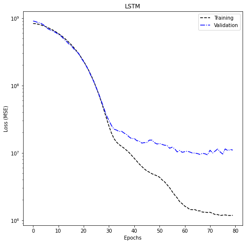

```python
%%skip $SKIP_RETRAIN_LSTM

fig = plot_learning_curves(histLSTM,modeltype,f'./{modeltype}/learningcurve_{namespace}.png')
```

Load best model

```python
model_best_tuned_MS_LSTM = keras.models.load_model(f"./{modeltype}/my_best_model_{namespace}.h5")
model_best_tuned_MS_LSTM.summary()
```

```
Model: "sequential_1"
_________________________________________________________________
Layer (type)                 Output Shape              Param #
=================================================================
lstm_5 (LSTM)                (None, None, 80)          34240
_________________________________________________________________
batch_normalization_5 (Batch (None, None, 80)          320
_________________________________________________________________
lstm_6 (LSTM)                (None, None, 80)          51520
_________________________________________________________________
batch_normalization_6 (Batch (None, None, 80)          320
_________________________________________________________________
lstm_7 (LSTM)                (None, None, 80)          51520
_________________________________________________________________
batch_normalization_7 (Batch (None, None, 80)          320
_________________________________________________________________
lstm_8 (LSTM)                (None, None, 80)          51520
_________________________________________________________________
batch_normalization_8 (Batch (None, None, 80)          320
_________________________________________________________________
lstm_9 (LSTM)                (None, 80)                51520
_________________________________________________________________
dense_2 (Dense)              (None, 80)                6480
_________________________________________________________________
leaky_re_lu_1 (LeakyReLU)    (None, 80)                0
_________________________________________________________________
batch_normalization_9 (Batch (None, 80)                320
_________________________________________________________________
dense_3 (Dense)              (None, 24)                1944
=================================================================
Total params: 250,344
Trainable params: 249,544
Non-trainable params: 800
_________________________________________________________________
```

```python
i=1
case_test = data_x_test[i].reshape((1,data_x_test[0].shape[0], data_x_test[0].shape[1]))

Y_test_predictions = pd.Series(model_best_tuned_MS_LSTM.predict(case_test).flatten(),index=pd.date_range(start=idx_test[i],freq='h',periods=24))
y_test_filtered = data_y_test0.loc[Y_test_predictions.index]
```

```python
eval_df = create_eval_df(Y_test_predictions,y_test_filtered)
```

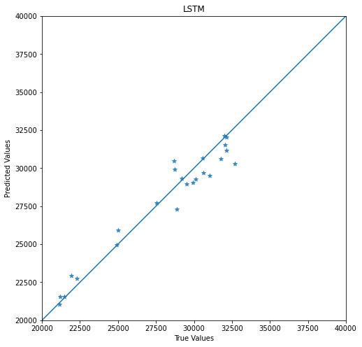

```python
fig = plot_accuracy(eval_df,modeltype,f'./{modeltype}/accuracy_{namespace}.png')
```

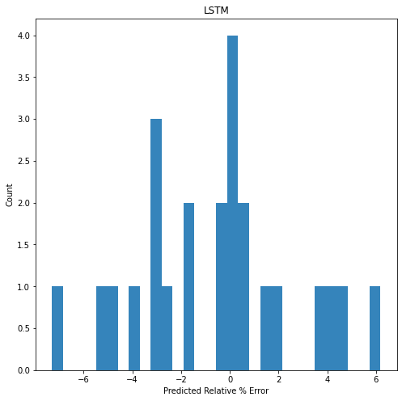

```python
fig = plot_error_variations(eval_df,modeltype,f'./{modeltype}/error_variations_{namespace}.png')
```

```python
abs_error_LSTM = abs(Y_test_predictions - y_test_filtered)/y_test_filtered*100
np.average(abs_error_LSTM)
```

```
nan
```

```python
r2_test = r2_score(y_test_filtered, Y_test_predictions)
print('R^2 score is  %3.2f' %r2_test)
```

```
R^2 score is  0.94
```

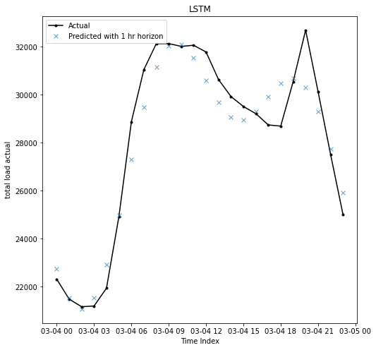

```python
fig = plot_predictions(eval_df,1,modeltype,feature,f'./{modeltype}/predictions_{namespace}.png')
```

```python
idx_prediction = pd.date_range(start=idx_test[0],freq='h',periods=len(idx_test)+24)
y_test_filtered2 = data_y_test0.loc[idx_prediction]
```

```python
fig = go.Figure()
df_pred =pd.DataFrame(index=y_test_filtered2.index)
fig.add_trace(go.Scatter(x = y_test_filtered2.index,y=y_test_filtered2[feature]))
for i in range(len(data_x_test)):
    case_test = data_x_test[i].reshape((1,data_x_test[0].shape[0], data_x_test[0].shape[1]))
    Y_test_predictions = pd.Series(model_best_tuned_MS_LSTM.predict(case_test).flatten(),index=pd.date_range(start=idx_test[i],freq='h',periods=24))
    df_pred[f'pred_{i}'] = Y_test_predictions
    fig.add_trace(go.Scatter(x = Y_test_predictions.index,y=Y_test_predictions,mode='markers'))

df_pred['mean'] = df_pred.mean(axis=1)
df_pred['median'] = df_pred.median(axis=1)
fig.add_trace(go.Scatter(x = y_test_filtered2.index,y=df_pred['mean']))
fig.add_trace(go.Scatter(x = y_test_filtered2.index,y=df_pred['median']))
fig.show()
eval_df2  =create_eval_df(df_pred['mean'],y_test_filtered2)
```

```python
r2_test = r2_score(y_test_filtered2[:-1],df_pred['mean'][:-1])
print('R^2 score is  %3.2f' %r2_test)
```

```
R^2 score is  0.38
```

## ED-LSTM Hyperparameter Tuning

Scale the input data

```python
scaled_df = combined_df.copy(deep=True)
featuresToScale = scaled_df.columns
sX = pp.StandardScaler(copy=True)
scaled_df.loc[:,featuresToScale] = sX.fit_transform(scaled_df[featuresToScale])
```

Create Train Validation Test Split

```python
train_start = '2015-01-01'
validation_start = '2017-01-01'
test_start = '2017-03-01'
test_end = '2017-03-14'
feature = 'total load actual'
namespace= 'MS_EDLSTM_LOAD_HPT'
modeltype = 'EDLSTM'
feature_df = combined_df[[feature]]
data_x_train0,data_x_val0,data_x_test0,data_y_train0,data_y_val0,data_y_test0 = create_test_train_split(scaled_df,feature_df,train_start,test_start,test_end,validation_start=validation_start)
```

Convert to (sample,timestep,feature) format

```python
data_x_train,data_y_train,idx_train = convert_to_sample_time_feature(data_x_train0,data_y_train0,72,24,32)
data_x_test,data_y_test,idx_test = convert_to_sample_time_feature(data_x_test0,data_y_test0,72,24,32)
data_x_val,data_y_val,idx_val = convert_to_sample_time_feature(data_x_val0,data_y_val0,72,24,32)
```

```python
print(data_x_train.shape,data_y_train.shape)
print(data_x_val.shape,data_y_val.shape)
print(data_x_test.shape,data_y_test.shape)
```

```
(17416, 72, 26) (17416, 24)
(1288, 72, 26) (1288, 24)
(168, 72, 26) (168, 24)
```

Define LSTM Model

```python
def build_model_ED_LSTM(hp):
  n_timesteps, n_features, n_outputs = data_x_train.shape[1], data_x_train.shape[2], data_y_train.shape[1]
  model = models.Sequential()
  # Encoder
  model.add(layers.LSTM(hp.Int('Neurons',min_value=32,max_value=96,step=16), return_sequences=True,input_shape=(None, n_features), stateful=False))
  model.add(layers.BatchNormalization())

  for i in range(hp.Int('n_layers',1,4,1)):
    model.add(layers.LSTM(hp.Int('Neurons',min_value=32,max_value=96,step=16), return_sequences=True, stateful=False))
    model.add(layers.BatchNormalization())

  model.add(layers.LSTM(hp.Int('Neurons',min_value=32,max_value=96,step=16), return_sequences=False, stateful=False))
  model.add(layers.BatchNormalization())

  # Repeat Vector
  model.add(layers.RepeatVector(n_outputs))

  # Decoder
  model.add(layers.LSTM(hp.Int('Neurons',min_value=32,max_value=96,step=16), return_sequences=True,stateful=False))
  model.add(layers.BatchNormalization())

  for i in range(hp.Int('n_layers',1,4,1)):
      model.add(layers.LSTM(hp.Int('Neurons',min_value=32,max_value=96,step=16), return_sequences=True, stateful=False))
      model.add(layers.BatchNormalization())

  model.add(layers.LSTM(hp.Int('Neurons',min_value=32,max_value=96,step=16), return_sequences=True,stateful=False))
  model.add(layers.BatchNormalization())

  # End
  model.add(layers.TimeDistributed(layers.Dense(1)))


  model.compile(optimizer='Adam',loss='mse',metrics='mae')
  return model
```

```python
tuner = kt.RandomSearch(
    build_model_ED_LSTM,
    objective='val_loss',
    max_trials=10,
    executions_per_trial = 1,
    directory = "./hpt_ED_LSTM/",
    project_name="Load")
tuner.search_space_summary()
```

```
INFO:tensorflow:Reloading Oracle from existing project ./hpt_ED_LSTM/Load\oracle.json
INFO:tensorflow:Reloading Tuner from ./hpt_ED_LSTM/Load\tuner0.json
Search space summary
Default search space size: 2
Neurons (Int)
{'default': None, 'conditions': [], 'min_value': 32, 'max_value': 96, 'step': 16, 'sampling': None}
n_layers (Int)
{'default': None, 'conditions': [], 'min_value': 1, 'max_value': 4, 'step': 1, 'sampling': None}
```

```python
myCheckpointLSTM= keras.callbacks.ModelCheckpoint(f"./{model_type}/my_best_model_{namespace}.h5", save_best_only=True)
myEarly_stoppingLSTM = keras.callbacks.EarlyStopping(patience=10,restore_best_weights=True)
```

```python
num_epochs = 150
batch_size = 32
```

```python
tuner.search(data_x_train,data_y_train,epochs=150,validation_data=(data_x_val,data_y_val),batch_size=batch_size,callbacks=[myCheckpointLSTM,myEarly_stoppingLSTM])
```

```
INFO:tensorflow:Oracle triggered exit
```

```python
tuner.results_summary()
```

```
Results summary
Results in ./hpt_ED_LSTM/Load
Showing 10 best trials
Objective(name='val_loss', direction='min')
Trial summary
Hyperparameters:
Neurons: 80
n_layers: 2
Score: 6554375.0
Trial summary
Hyperparameters:
Neurons: 64
n_layers: 1
Score: 6809337.0
Trial summary
Hyperparameters:
Neurons: 80
n_layers: 3
Score: 7097545.0
Trial summary
Hyperparameters:
Neurons: 64
n_layers: 3
Score: 7223991.5
Trial summary
Hyperparameters:
Neurons: 96
n_layers: 3
Score: 8044475.5
Trial summary
Hyperparameters:
Neurons: 32
n_layers: 4
Score: 9238089.0
Trial summary
Hyperparameters:
Neurons: 48
n_layers: 2
Score: 9645877.0
Trial summary
Hyperparameters:
Neurons: 32
n_layers: 2
Score: 9690508.0
Trial summary
Hyperparameters:
Neurons: 48
n_layers: 3
Score: 10513382.0
Trial summary
Hyperparameters:
Neurons: 32
n_layers: 3
Score: 10803020.0
```

```python
best_models = tuner.get_best_models()
best_hps = tuner.get_best_hyperparameters(5)
```

[output not shown]

```python
best_hps[0]
```

```
<keras_tuner.engine.hyperparameters.HyperParameters at 0x1b49d85d3a0>
```

```python
%%skip $SKIP_RETRAIN_ED_LSTM

model_tuned_ED_LSTM= build_model_ED_LSTM(best_hps[0])
history_tuned_ED_LSTM = model_tuned_ED_LSTM.fit(data_x_train, data_y_train, epochs=num_epochs, batch_size=batch_size, validation_data=(data_x_val, data_y_val) ,
                                 callbacks=[myCheckpointLSTM,myEarly_stoppingLSTM])
```

```python
%%skip $SKIP_RETRAIN_ED_LSTM

histEDLSTM = pd.DataFrame(history_tuned_ED_LSTM.history)
histEDLSTM['epoch'] = history_tuned_ED_LSTM.epoch
```

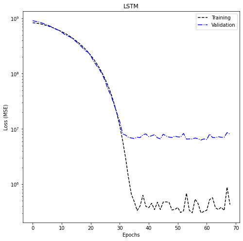

```python
%%skip $SKIP_RETRAIN_ED_LSTM

fig = plot_learning_curves(histEDLSTM,model_type,f"./{modeltype}/learningcurve_{namespace}.png")
```

Load best model

```python
model_best_tuned_ED_LSTM = keras.models.load_model(f"./{modeltype}/my_best_model_{namespace}.h5")
model_best_tuned_ED_LSTM.summary()
```

```
Model: "sequential_1"
_________________________________________________________________
Layer (type)                 Output Shape              Param #
=================================================================
lstm_8 (LSTM)                (None, None, 80)          34240
_________________________________________________________________
batch_normalization_8 (Batch (None, None, 80)          320
_________________________________________________________________
lstm_9 (LSTM)                (None, None, 80)          51520
_________________________________________________________________
batch_normalization_9 (Batch (None, None, 80)          320
_________________________________________________________________
lstm_10 (LSTM)               (None, None, 80)          51520
_________________________________________________________________
batch_normalization_10 (Batc (None, None, 80)          320
_________________________________________________________________
lstm_11 (LSTM)               (None, 80)                51520
_________________________________________________________________
batch_normalization_11 (Batc (None, 80)                320
_________________________________________________________________
repeat_vector_1 (RepeatVecto (None, 24, 80)            0
_________________________________________________________________
lstm_12 (LSTM)               (None, 24, 80)            51520
_________________________________________________________________
batch_normalization_12 (Batc (None, 24, 80)            320
_________________________________________________________________
lstm_13 (LSTM)               (None, 24, 80)            51520
_________________________________________________________________
batch_normalization_13 (Batc (None, 24, 80)            320
_________________________________________________________________
lstm_14 (LSTM)               (None, 24, 80)            51520
_________________________________________________________________
batch_normalization_14 (Batc (None, 24, 80)            320
_________________________________________________________________
lstm_15 (LSTM)               (None, 24, 80)            51520
_________________________________________________________________
batch_normalization_15 (Batc (None, 24, 80)            320
_________________________________________________________________
time_distributed_1 (TimeDist (None, 24, 1)             81
=================================================================
Total params: 397,521
Trainable params: 396,241
Non-trainable params: 1,280
_________________________________________________________________
```

```python
i=1
case_test = data_x_test[i].reshape((1,data_x_test[0].shape[0], data_x_test[0].shape[1]))
Y_test_predictions = pd.Series(model_best_tuned_ED_LSTM.predict(case_test).flatten(),index=pd.date_range(start=idx_test[i],freq='h',periods=24))
y_test_filtered = data_y_test0.loc[Y_test_predictions.index]
```

```python
eval_df = create_eval_df(Y_test_predictions,y_test_filtered)
```

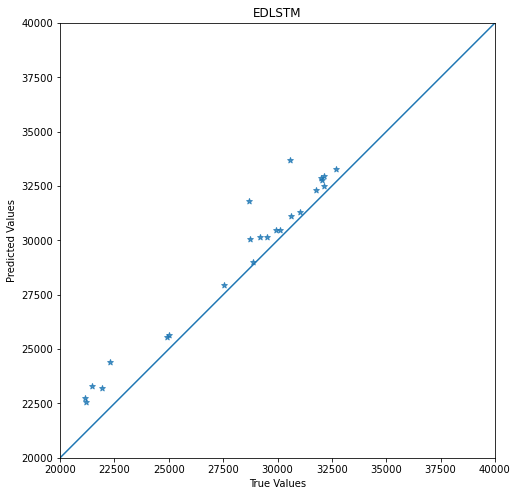

```python
fig = plot_accuracy(eval_df,modeltype,f"./{modeltype}/accuracy_{namespace}.png")
```

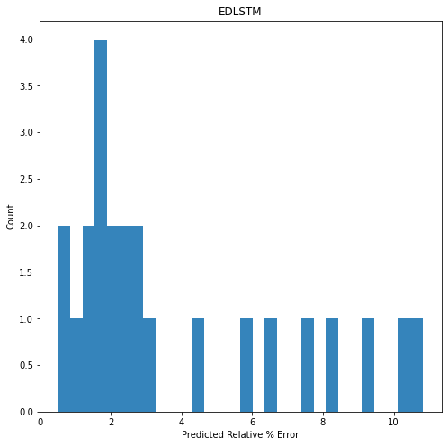

```python
fig = plot_error_variations(eval_df,modeltype,f"./{modeltype}/error_variations_{namespace}.png")
```

```python
#Calculating the mean absolutepercentage error:
abs_error_ED_LSTM = abs(Y_test_predictions - y_test_filtered)/y_test_filtered*100
np.average(abs_error_ED_LSTM)
```

```
nan
```

```python
#Calculating R2 value:
r2_test = r2_score(y_test_filtered, Y_test_predictions)
print('R^2 score is  %3.2f' %r2_test)
```

```
R^2 score is  0.89
```

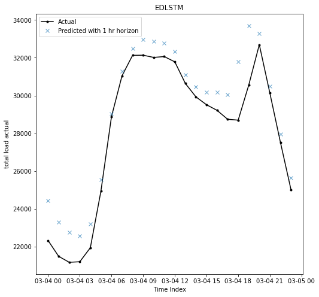

```python
fig=plot_predictions(eval_df,1,modeltype,feature,f"./{modeltype}/predictions_{namespace}.png")
```

```python
idx_prediction = pd.date_range(start=idx_test[0],freq='h',periods=len(idx_test)+24)
y_test_filtered2 = data_y_test0.loc[idx_prediction]
```

```python
fig = go.Figure()
df_pred =pd.DataFrame(index=y_test_filtered2.index)
fig.add_trace(go.Scatter(x = y_test_filtered2.index,y=y_test_filtered2[feature]))
for i in range(len(data_x_test)):
    case_test = data_x_test[i].reshape((1,data_x_test[0].shape[0], data_x_test[0].shape[1]))
    Y_test_predictions = pd.Series(model_best_tuned_ED_LSTM.predict(case_test).flatten(),index=pd.date_range(start=idx_test[i],freq='h',periods=24))
    df_pred[f'pred_{i}'] = Y_test_predictions
    #fig.add_trace(go.Scatter(x = Y_test_predictions.index,y=Y_test_predictions,mode='markers'))

df_pred['mean'] = df_pred.mean(axis=1)
df_pred['median'] = df_pred.median(axis=1)
fig.add_trace(go.Scatter(x = y_test_filtered2.index,y=df_pred['mean']))
fig.show()
eval_df2  =create_eval_df(df_pred['mean'],y_test_filtered2)
```

```python
#Calculating R2 value:
r2_test = r2_score(y_test_filtered2[:-1],df_pred['mean'][:-1])
print('R^2 score is  %3.2f' %r2_test)
```

```
R^2 score is  0.85
```

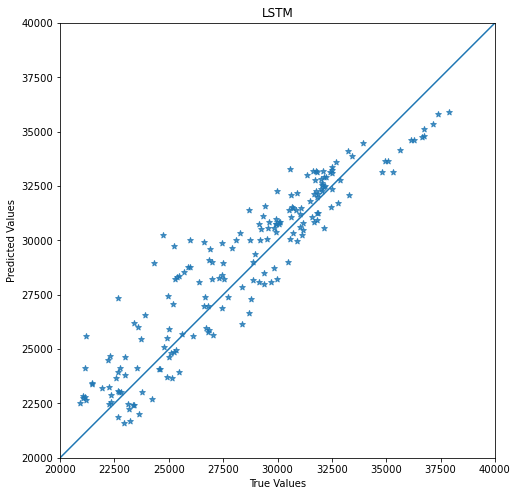

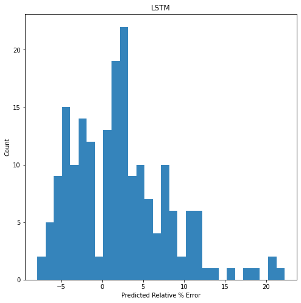

```python
fig = plot_accuracy(eval_df2,model_type,f"./{model_type}/accuracy2_{namespace}.png")
fig = plot_error_variations(eval_df2,model_type,f"./{model_type}/error_variations2_{namespace}.png")
```